# Fourier_Transform

傅里叶变换是用一种特殊的正交基（正交函数）对原函数做线性变换。

### 正交基--向量

简单的理解：对于一个 $ n $ 维向量 $ \vec{a} $，我们总可以找到一组 $ n $ 维正交基 $ \{ \vec{e_1}, \vec{e_2}, \vec{e_3} , ... , \vec{e_n} \} $，使得：

$$ \vec{a} = c_1\vec{e_1} + c_2\vec{e_2} + c_3\vec{e_3} + ... + c_n\vec{e_n} $$

如果想求这些系数 $ \{ c_1, c_2, c_3, ... , c_n \} $，可以分别在等式两边用每个正交基做内积。因为我们知道： $$ < \vec{e_i, e_j} > = \left\{ \begin{aligned} 0, \quad i \neq j \\ 1, \quad i = j \end{aligned} \right.$$

### 正交基--函数

函数是一种映射关系，一般可以记作：$\{f:x\rightarrow y\} $。

但是对于常见的函数，其定义域往往是固定的。比如实变函数，定义域是实数域或者实数域的一部分。

对于函数 $ \{f:x\rightarrow y\} $，常常把定义域中 $ x $ 对应的唯一的值 $ y $ 记作 $ f(x) $。如果我们把所有可能的 $ x $ 按固定顺序排列起来，则函数值也可以同样的顺序排列起来。

比如，假设定义域是自然数，$ x $ 的所有取值 $ \{ 0, 1, 2, 3, ... \} $ ，对应的 $ f(x) $：$ \{f(0), f(1), f(2), f(3), ... \}$。定义域是连续的话也可以类比这样。

这样，定义域、值域分别可以看作两个无穷维的向量。对于函数 $\{f:x\rightarrow y, x in \mathbb{Q}\}$ ，其定义域可以看作无穷维向量 $[0,1,2,3,...]$，对应的所有函数值，也可以看作一个无穷维向量 $[f(0),f(1),f(2),f(3),... ]$。

定义域、值域是连续的也可以用微分的方法，类比思考。

所以如果想要把一个函数用“正交基”来线性表示，就需要使用正交的函数。 正交函数是正交向量的推广。 对于向量 $ u=(a,b), \ v=(c,d) $，其内积 $ u\bullet v = ac + bd $。 推广到函数 $ f(x), \ g(x) $，把它们也用向量示意： $$ U = \{f(0), f(1), f(2), ..., f(N) \}, \quad V = \{g(0), g(1), g(2), ..., g(N) \} $$ 此时，推广的函数内积： $$ U \bullet V = f(0)g(0)*1 + f(1)g(1)$$ 上面每个分量的间隔是1，实际上，这个间隔可以是无穷小： $$ U = \{ f(-\infty), ..., f(0), f(0 + \Delta x), f(0 + 2\Delta x), ..., f(+\infty) \} $$ $$ V = \{ g(-\infty), ..., g(0), g(0 + \Delta x), g(0 + 2\Delta x), ..., g(+\infty) \} $$ 此时：

$$ U \bullet V = f(-\infty)g(-\infty)\Delta x + ... + f(0)g(0)\Delta x + f(0 + \Delta x)g(0 + \Delta x)\Delta x + f(0 + 2\Delta x)g(0 + 2\Delta x)\Delta x + ... + f(+\infty)g(+\infty)\Delta x \\ = \int^{+\infty}_{-\infty}f(x)g(x)dx$$

这里的 $ f(x), g(x) $ 都是实值函数，如果是虚函数，则要加上共轭： $$ <f(x), g(x)> = \int^{+\infty}_{-\infty}f(x)\overline{g(x)}dx $$ 其中 $ \overline{g(x)} $ 表示 $ g(x) $ 的共轭。 共轭的目的是将虚数（二维）映射到标量（一维）。

### 正交基恢复

假设 $ G = \{g_1, g_2, g_3, ... \} $ 是一组正交基，函数 $ \{f:x\rightarrow y\} $ 在 $G$ 上的分解：$f\bullet G = \{a_1, a_2, a_3, ...\} $，则 $ f $ 可以表示为：$ f = a_1g_1 + a_2g_2 + a_3g_3 ... $

### 数学定义

#### 正交基

在线性代数中，一个内积空间的正交基（orthogonal basis）是元素两两正交的基。称基中的元素为基向量。假若，一个正交基的基向量的模长都是单位长度1，则称这正交基为标准正交基或"规范正交基"（Orthonormal basis）。

#### 内积空间（英语：Inner product space）

是数学中的线性代数里的基本概念，是增添了一个额外的结构的向量空间。这个额外的结构叫做内积或标量积。内积将一对向量与一个标量连接起来，允许我们严格地谈论向量的“夹角”和“长度”，并进一步谈论向量的正交性。（比如，可以定义内积为0的一对非0向量互相垂直）。内积空间由欧几里得空间抽象而来（内积是点积的抽象），这是泛函分析讨论的课题。

内积空间有时也叫做准希尔伯特空间（pre-Hilbert space），因为由内积定义的距离完备化之后就会得到一个希尔伯特空间。在早期的著作中，内积空间被称作酉空间，但这个词现在已经被淘汰了。在将内积空间称为酉空间的著作中，“内积空间”常指任意维（可数或不可数）的欧几里德空间。

以上定义来自维基百科。从定义上看，内积将一对向量和标量连接起来。

**向量的点乘是一种内机，积分也可以是一种内积。**

比如，在欧几里得空间$\mathbb{R}^3$中，集合：$\{e_1=(1,0,0), e_2=(0,1,0), e_3=(0,0,1)\}$组成一组标准正交基。

再比如，由$f_n=e^{2\pi jnx}$定义的集合：$\{f_n : n \in \mathbb{Z} \}$组成在复勒贝格空间$L^2([0,1])$上的一组标准正交基。

在数学中，$L^p$空间是由$p$次可积函数组成的空间；对应的$L^p$空间是由$p$次可和序列组成的空间。它们有时叫做勒贝格空间。

### 傅立叶变换

###### 一维傅里叶变换

$$ F(\omega) = \int^{+\infty}_{-\infty} f(x)e^{-2\pi j\omega x}dx $$

###### 二维傅里叶变换

$$ F(u, v) = \int^{+\infty}_{-\infty} \int^{+\infty}_{-\infty} f(x, y) e^{-2\pi j(ux+vy)}dxdy $$

### 傅立叶逆变换

根据上面从基函数恢复原函数的方法： $$ f(x)=\int^{+\infty}_{-\infty}F(\omega)e^{-2\pi j\omega x}d\omega $$

正交的函数有很多，傅里叶所选用的，是其中一种：$ \{f_{\omega}(x) = e^{2\pi j \omega x}, \omega \in \mathbb{R} \}$。

这个函数具有特征：

$$ <f_{\omega_1}(x), f_{\omega_2}(x)> = \int^{+\infty}_{-\infty}f_{\omega_1}(x) \overline{f_{\omega_2}(x)}dx = \int^{+\infty}_{-\infty}e^{2\pi j\omega_1 x} e^{-2\pi \omega_2 x} dx = \int^{+\infty}_{-\infty}e^{2\pi j(\omega_1 - \omega_2) x} dx = \left\{ \begin{aligned} 0, \quad \omega_1 \neq \omega_2 \\ 1, \quad \omega_1 = \omega_2 \end{aligned} \right. $$

注意 $ f(x) $ 是复函数，所以内积要对其求共轭： $ \overline{f(x)} = \overline{e^{2\pi j\omega x}} = e^{-2\pi j\omega x}$

$ \int^{+\infty}_{-\infty}e^{2\pi j\omega x} dx $ 的求解如下： $$ \int^{+N}_{-N}e^{2\pi j\omega x} dx = \int^{+N}_{-N}e^{2\pi j\omega x} \frac{1}{2\pi j\omega} d({2\pi j\omega x}) = \frac{1}{2\pi j\omega} \int^{+N}_{-N}e^{2\pi j\omega x} d({2\pi j\omega x}) = \frac{1}{2\pi j\omega} e^{2\pi j\omega x}\bigg|^{+N}_{-N} = \frac{1}{2\pi j\omega}(e^{2\pi j\omega N} - e^{-2\pi j\omega N}) $$

$$ \frac{1}{2\pi j\omega}(e^{2\pi j\omega N} - e^{-2\pi j\omega N}) = \frac{1}{2\pi j\omega}(cos({2\pi \omega N}) + jsin({2\pi \omega N}) - cos({-2\pi \omega N}) - jsin({-2\pi \omega N})) )) = \frac{1}{2\pi j\omega}(2jsin({2\pi \omega N})) = \frac{1}{\pi j\omega}(jsin({2\pi \omega N})) $$$$ \int^{+N}_{-N}e^{2\pi j\omega x} dx = \frac{1}{\pi j\omega}(jsin({2\pi \omega N})) = \frac{1}{\pi \omega}(sin({2\pi \omega N})) $$$$ \lim_{N\to +\infty}\int^{+N}_{-N}e^{2\pi j\omega x} dx = \lim_{N\to +\infty}\frac{1}{\pi \omega}(sin({2\pi \omega N})) $$

$ \lim_{N\to +\infty}\frac{1}{\pi x}(sin({2\pi x N})) $ 这个极限是不存在的，但是，它在 $ (-\infty, +\infty) $ 上的积分存在。

$$ \int^{+\infty}_{-\infty}\lim_{N\to +\infty}f(x)\frac{sin(2\pi x N)}{\pi x} dx = \int^{+\infty}_{-\infty}\lim_{N\to +\infty}f(\frac{x}{2\pi N})\frac{sin(x)}{\frac{\pi x}{2\pi N}} d\frac{x}{2\pi N} = \int^{+\infty}_{-\infty}\lim_{N\to +\infty}f(\frac{x}{2\pi N})\frac{sin(x)}{\pi x} dx = \int^{+\infty}_{-\infty}\lim_{N\to +\infty}f(\frac{x}{2\pi N})\frac{sin(x)}{\pi x} dx $$$$ \int^{+\infty}_{-\infty}\lim_{N\to +\infty}f(\frac{x}{2\pi N})\frac{sin(x)}{\pi x} dx = \int^{+\infty}_{-\infty}f(0)\frac{sin(x)}{\pi x}dx = f(0)\int^{+\infty}_{-\infty}\frac{sin(x)}{\pi x}dx $$

$$ \int^{+\infty}_0 \frac{sin(x)}{x}dx $$

被称为狄利克雷(Dirichlet)积分。

$$ f(x) = \frac{sin(x)}{x} $$

函数的图像：

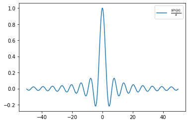

```python
import numpy as np
import matplotlib.pyplot as plt


ax = plt.figure().add_subplot()

# Prepare arrays x, y, z
x = np.linspace(-50, 50, 1000)
y = np.sin(x) / x
ax.plot(x, y, label=r'$\frac{sin(x)}{x}$')
ax.legend()

plt.show()
```

要证明狄利克雷积分，初等方法可以用引入收敛因子 $ e^{-px} $ 凑出来，其中 $ p \in [0, +\infty) $： $$ \int^{+\infty}_0 e^{-px}dx = \frac{1}{-p}\int^{+\infty}_0 e^{-px}d(-px) $$ 令 $ u = -px $： $$ \frac{1}{-p}\int^{+\infty}_0 e^{-px}d(-px) = \frac{1}{-p}\int^{-\infty}_{0} e^{u}d(u) = \frac{1}{-p} e^u\bigg|^{-\infty}_{0} = \frac{1}{p} $$

整理一下： $$ \int^{+\infty}_0 e^{-px}dx = \frac{1}{p} $$

两边不断对 $ p $ 求导： $$ \int^{+\infty}_0 x^n e^{-px}dx = \frac{n!}{p^{n+1}} $$

将 $ e^{-px} $ 引入 $ \int^{+\infty}_0 \frac{sin(x)}{x}dx $，$ sin(x) $ 在 $ x = 0 $ 处的泰勒展开： $$ sin(x) = sin(0) + \frac{xsin'(0)}{1!} + \frac{x^2sin''(0)}{2!} + ... = 0 + \frac{x}{1} - \frac{x^3}{3!} + \frac{x^5}{5!} + ... $$

$$ \int^{+\infty}_0 \frac{sin(x)}{x} e^{-px}dx = \int^{+\infty}_0(1 - \frac{x^2}{3!} + \frac{x^4}{5!} - ...)e^{-px}dx = \int^{+\infty}_0 e^{-px} dx - \int^{+\infty}_0 \frac{x^2}{3!} e^{-px} dx + \int^{+\infty}_0 \frac{x^4}{5!} e^{-px} dx = \frac{1}{a} - \frac{1}{3a^3} + \frac{1}{5a^5} - ... = arccot(a) $$

令 $ a\to0 $ 得 $ \int^{+\infty}_0\frac{sin(x)}{x}dx = \frac{\pi}{2} $。

因为 $ frac{sin(x)}{x} $ 关于 $ 0 $ 点对称，所以 $ \int^{+\infty}_{-\infty}\frac{sin(x)}{x}dx = \pi $

令： $$ f(\omega) = \int^{+\infty}_{-\infty}e^{2\pi j(\omega) x} dx $$ 则： $$ f(\omega) = \left\{ \begin{aligned} \infty, \quad \omega = 0 \\ 0, \quad \omega \neq 0 \end{aligned} \right. $$ 且： $$ \int^{+\infty}_{-\infty}f(\omega)d\omega = \frac{\int^{+\infty}_{-\infty}\frac{sin(\omega)}{\omega}d\omega}{\pi} = 1 $$

引入 $ \delta $ 函数定义： $$ \delta(x) = \left\{ \begin{aligned} 0, \quad x \neq 0 \\ \infty, \quad x = 0 \end{aligned} \right. \\ \int^{+\infty}_{-\infty}\delta(x)dx = 1 $$

$ \delta $ 函数具有选择性： $$ \int^{+\infty}_{-\infty}f(x)\delta(x-x_0)d(x) = f(x_0) $$

由上面的推导： $$ \int^{+\infty}_{-\infty}e^{2\pi j(\omega_1 - \omega_2) x} dx = \delta(\omega_1 - \omega_2) $$

傅里叶变化要解决的问题：

假如想把一个函数，表达成利用无穷多个像上式那样的东西的和，分配的系数分别是多少呢？

也就是求 $ a_{\omega} $ 使得：

$$ f(x) = \int^{+\infty}_{-\infty} a_{\omega} e^{2\pi j \omega x} d\omega $$

这里的 $ a_{\omega} $ 可能不是一个标量，而是一个关于 $ \omega $ 的函数 $ a_{\omega} ( \omega ) $。

如何求 $ a_{\omega} $ 呢？同样是利用正交属性去做内积。 已知, 对于任意一个给定的 $ \omega $，有： $$ \int^{+\infty}_{-\infty}f(x) e^{-2\pi \omega' jx}dx = \int^{+\infty}_{-\infty}\int^{+\infty}_{-\infty}a_{\omega}(\omega) e^{2\pi j \omega x} d\omega \quad e^{-2\pi j \omega' x} dx = \int^{+\infty}_{-\infty}\int^{+\infty}_{-\infty}a_{\omega}(\omega) e^{2\pi j \omega x} e^{-2\pi j \omega' x} d\omega dx = \int^{+\infty}_{-\infty}\int^{+\infty}_{-\infty}a_{\omega}(\omega) e^{2\pi j (\omega - \omega') x} dx d\omega $$

交换积分顺序： $$\int^{+\infty}_{-\infty}\int^{+\infty}_{-\infty}a_{\omega}(\omega) e^{2\pi j (\omega - \omega') x} dx d\omega = \int^{+\infty}_{-\infty} a_{\omega}(\omega) \int^{+\infty}_{-\infty} e^{2\pi j (\omega - \omega') x} dx d\omega $$

由上面 $ \delta $ 函数的定义和性质： $$\int^{+\infty}_{-\infty} a_{\omega}(\omega) \int^{+\infty}_{-\infty} e^{2\pi j (\omega - \omega') x} dx d\omega = \int^{+\infty}_{-\infty} a_{\omega}(\omega) \delta(\omega - \omega') d\omega = a_{\omega}(\omega') $$

综上： $$ \int^{+\infty}_{-\infty}f(x) e^{-2\pi \omega' jx}dx = a_{\omega}(\omega') $$

傅立叶变换是一种基变换。基并不一定是某个坐标轴的单位向量，它也可以是函数。 这里先介绍一下关于基的概念。

对于 $\{ f_n : f_n = e^{2\pi jnx}, n \in \mathbb{z} \}$ 这组基，一种可视化方法是这样的：

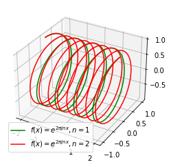

```python
import numpy as np
import matplotlib.pyplot as plt


ax = plt.figure().add_subplot(projection='3d')

# Prepare arrays x, y, z
x = np.linspace(-2, 2, 1000)
cnames = ['black', 'green', 'red']
for n in range(1, 3):
    y = np.sin(2*np.pi*n*x)
    z = np.cos(2*np.pi*n*x)

    ax.plot(x, y, z, label=r'$f(x)=e^{2\pi jnx}, n = %d$'%n, color=cnames[n])
    ax.legend()

plt.show()
```

可以看到，这组基表现为“频率”不同。